# 十二月第四周

2018年 一月 09日

## 一、清醒时间安排情况

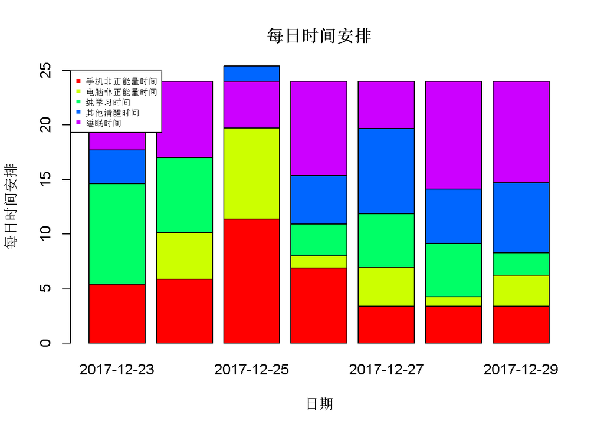

图中反映了本期7天每日时间的构成及其变化情况

启动时间，反映了本人自起床开始到做本日第一件事，平均要花1.65小时，占全部清醒时间的9.78%。

纯学习时间，平均为4.47小时，占清醒时间比重为26.49%。

手机非正能量时间每天为5.65小时,占清醒时间比重为33.48%。

电脑非正能量时间平均每天为3.81小时,占清醒时间比重为22.56%。

## 二、睡眠状况

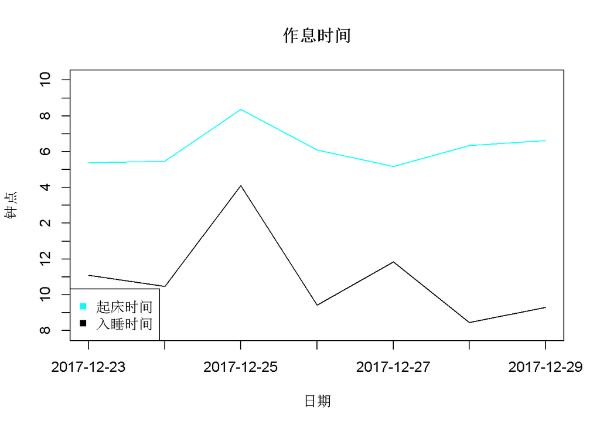

“作息时间”图反映了本期本人每日的入睡与起床时间，在这一期间，本人平均每天10点57分入睡，6点12分起床，睡眠时间平均为7.11小时。

入睡时间与起床时间没有显著的相关关系，相较而言，起床时间的波动要比入睡时间更小。

从线性趋势上看，总睡眠时间趋向增加，深睡眠时间趋向减少，睡眠质量向减少发展。

## 三、学习状况

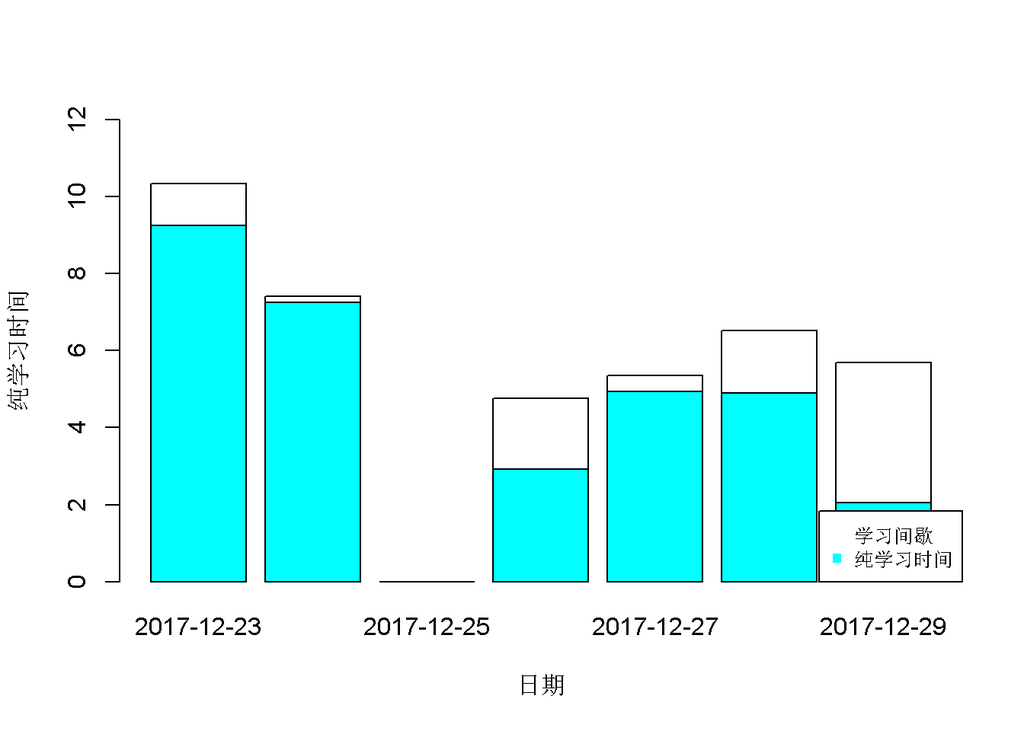

本期平均每日毛学习时间/工作时间为5.72小时。

纯学习时间/工作时间为4.47小时。

时间利用比为1.28，处于适度轻松的学习状况。

### 核心时间

核心时间指的是完全由自主学习构成，推动个人发展的学习或工作时间；最近一周的核心时间为6.47小时，占纯学习/工作时间的21%。

## 四、娱乐时间

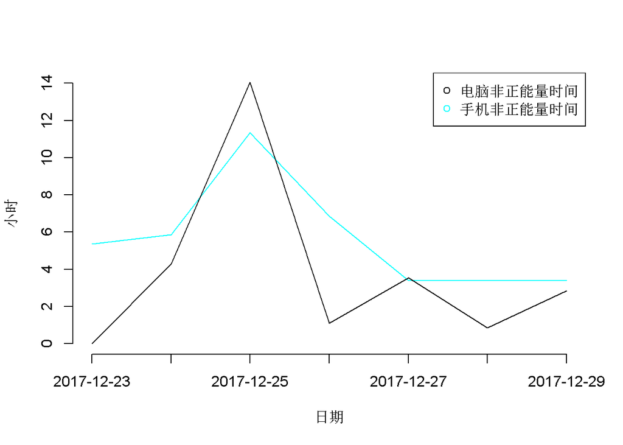

平均每日使用手机时间为5.97小时，呈减少趋势；其中非正能量时间5.65小时，呈减少趋势，与纯学习时间 没有显著的相关关系。

平均每日使用电脑时间为5.63小时；其中非正能量时间为3.81小时，呈减少趋势，与纯学习时间 没有显著的相关关系。

两者之和 与纯学习时间 没有显著的相关关系。